Bootstrapping and Simulations with R Aditya Dube Saturday, May 20, 2023

# Loading Packages

```r
library(tidyverse)
library(stringr)
library(broom)
library(ggthemes)
library(moments)
```

# Sampling from vectors

## Use the sample function to simulate 100000 dice rolls, storing the result in a vector called rolls. What proportion of rolls were each number?

```r
rolls <- sample(1:6,100000, replace = TRUE)
table(rolls) / length(rolls)
```

```
## rolls
##       1       2       3       4       5       6
## 0.16724 0.16653 0.16619 0.16531 0.16692 0.16781
```

## Using the rle() function, what are the most consecutive rolls with the same die value?

```r
rle_result <- rle(rolls)

# Find the maximum length of consecutive values
max_consecutive <- max(rle_result$lengths)

# Print the maximum length
print(max_consecutive)
```

```
## [1] 7
```

## What is the total number of runs of each length?

```r
# Calculate the total number of runs of each length
runs_lengths <- table(rle_result$lengths)

# Print the results
print(runs_lengths)
```

```
##
##     1     2     3     4     5     6     7
## 69443 11553  1886   353    59    12     2
```

## What is the ratio of the number of runs of length 2 compared to the number of runs of length 1? What about the number of runs of length 3 compared to 2?

```r
# Calculate the ratio of runs of length 2 compared to length 1
ratio_2_to_1 <- runs_lengths[2] / runs_lengths[1]

# Calculate the ratio of runs of length 3 compared to length 2
ratio_3_to_2 <- runs_lengths[3] / runs_lengths[2]

# Print the results
print(ratio_2_to_1)
```

```
##         2
## 0.1663667
```

```r
print(ratio_3_to_2)
```

```
##         3
## 0.1632476
```

## What are these ratios close to?

## Answer: These are close to 1/6

# You try

## Randomly select 10 values from the fruit vector🍇🍉🍓🥝🍒that is available from the stringr package, and run your code several times. Does sample() use sampling with or without replacement by default?

```r
sample(fruit, size = 10)
```

```
##  [1] "orange"            "quince"            "jujube"
##  [4] "pomegranate"       "clementine"        "purple mangosteen"
##  [7] "boysenberry"       "fig"               "bell pepper"
## [10] "currant"
```

## Randomly select 10 values from the fruit vector, sampling with replacement. Resample 10 fruits until you obtain at least one duplicate fruit within a sample.

```r
sample(fruit, size=10, replace=TRUE)
```

```
##  [1] "rambutan"     "cantaloupe"   "orange"       "damson"       "pear"
##  [6] "olive"        "persimmon"    "star fruit"   "cantaloupe"   "blackcurrant"
```

## Set the seed value to 1989, and then sample 13 values from the fruit vector to reproduce the results below.

```r
set.seed(1989)
sample(fruit, size = 13)
```

```
##  [1] "salal berry"       "purple mangosteen" "durian"
##  [4] "rambutan"          "breadfruit"        "currant"
##  [7] "tamarillo"         "blackberry"        "raisin"
## [10] "dragonfruit"       "chili pepper"      "avocado"
## [13] "mango"
```

# Sampling from distributions

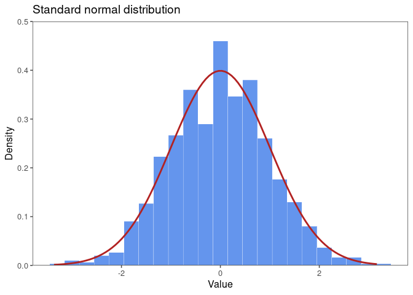

```r
# Set ggplot theme for visualizations
theme_set(ggthemes::theme_few())
# Set parameters that will be passed to `stat_function()`
n <- 1000
mean <- 0
sd <- 1
binwidth <- 0.3 # passed to geom_histogram and stat_function
myData <- data.frame(x = rnorm(n, mean, sd))
ggplot(myData, aes(x = x, mean = mean, sd = sd, binwidth = binwidth, n = n)) + geom_histogram(aes(y = ..density..), binwidth = binwidth,
colour = "white", fill = "cornflowerblue", size = 0.1) +
stat_function(fun = function(x) dnorm(x, mean = mean, sd = sd),
color = "firebrick", size = 1) +
labs(title = "Standard normal distribution",
x = "Value",
y = "Density") +
scale_y_continuous(limits = c(0, 0.5), expand = c(0, 0))
```

## Generate 100,000 values from a standard normal distribution, and calculate an estimate of the median (50th percentile) of the standard normal distribution using the quantile() function.

```r
set.seed(2023)
simValues<-rnorm(n=100000, mean=0, sd=1)

quantile(simValues, probs=0.50)
```

```
##          50%
## 0.0005823885
```

## Also calculate an estimate of the 97.5th percentile of the standard normal distributionusing the quantile() function. Note that the exact value of the 97.5th percentile can be found using qnorm(p = 0.975).

```r
quantile(simValues, probs=0.975)
```

```
##    97.5%
## 1.980451
```

```r
#We can get exact percentile using
qnorm(p=0.975)
```

```
## [1] 1.959964
```

# Example

## If Spongebob just arrived at the bus stop, what is his expected waiting time until the next bus comes?

```r
set.seed(1234)
# Set the minimum and maximum waiting time in minutes
min_waiting_time <- 0
max_waiting_time <- 20

# Number of Monte Carlo simulations
num_simulations <- 100000

# Simulate waiting times using the uniform distribution
waiting_times <- runif(num_simulations, min_waiting_time, max_waiting_time)

# Calculate the expected waiting time
mean(waiting_times)
```

```
## [1] 10.00982
```

## What is the median waiting time until the next bus comes for Spongebob?

```r
median(waiting_times)
```

```
## [1] 10.01568
```

## What is Spongebob’s expected waiting time until he catches a bus back to the Krusty Krab with Patrick?

```r
set.seed(1234)
# Set the waiting time parameters for Spongebob's bus
spongebob_min_waiting_time <- 0
spongebob_max_waiting_time <- 20

# Set the waiting time parameters for Patrick's bus
patrick_min_waiting_time <- 0
patrick_max_waiting_time <- 30

# Number of Monte Carlo simulations
num_simulations <- 100000

# Simulate waiting times for Spongebob and Patrick
spongebob_waiting_times <- runif(num_simulations, spongebob_min_waiting_time, spongebob_max_waiting_time)
patrick_waiting_times <- runif(num_simulations, patrick_min_waiting_time, patrick_max_waiting_time)

# Calculate the total waiting time until both Spongebob and Patrick catch the bus
total_waiting_times <- spongebob_waiting_times + patrick_waiting_times + 10

# Calculate the expected waiting time
expected_waiting_time <- mean(total_waiting_times)
expected_waiting_time
```

```
## [1] 34.99685
```

## What is Spongebob’s median waiting time until he catches a bus back to the Krusty Krab with Patrick?

```r
median(total_waiting_times)
```

```
## [1] 35.01234
```

## Construct and interpret a 95% confidence interval for the total waiting time in minutes for Spongebob until a bus comes for him and Patrick to take to the Krusty Krab using the quantile() function.

```r
# Calculate the 95% confidence interval
quantile(total_waiting_times, probs = 0.95)
```

```
##      95%
## 52.20574
```

```r
quantile(total_waiting_times, probs = 0.25)
```

```
##     25%
## 27.2915
```

## Interpret: Spongebob and Patrick can expect to catch a bus back to the Krusty Krab within 52.20574 minutes or less with a 95% probability. Spongebob and Patrick can expect to catch a bus back to the Krusty Krab within 27.2915 minutes or less with a 25% probability.

# Permutation & randomization tests

## Example

```r
# Simulating participant blood-pressure changes
set.seed(1994)
n1 <- 8
n2 <- 8
trialData <- tibble(Participant = 1:(n1 + n2),
Treatment = rep(c("Drug", "Placebo"), each = c(n1, n2)),
Change = c(rcauchy(n = n1, location = -3.5, scale = 5),
rcauchy(n = n2, location = 0, scale = 1)))
# Two-sample t-test
tResult <- t.test(x = trialData$Change[which(trialData$Treatment == "Drug")],
y = trialData$Change[which(trialData$Treatment == "Placebo")],
alternative = "less")
```

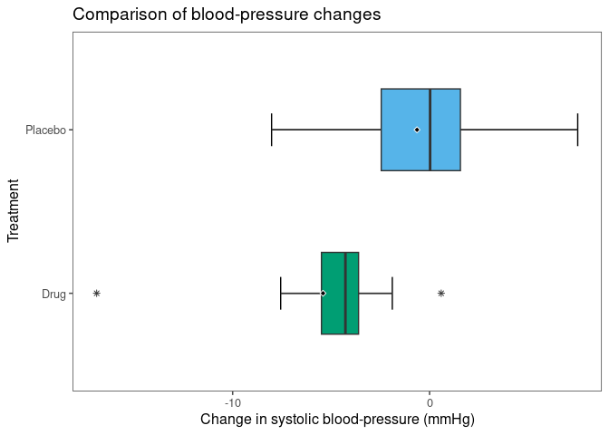

```r
trialData %>% ggplot(aes(x = Treatment, y = Change,
                         fill = Treatment)) +
  stat_boxplot(geom = "errorbar", width = 0.2, coef = 1.5) +
  stat_boxplot(geom = "boxplot", width = 0.5, coef = 1.5,
               outlier.shape = 8) +
  stat_summary(fun = "mean", geom = "point", shape = 23, fill = "black",
               color = "white") +
  scale_fill_manual(values = c("#009E73", "#56B4E9")) +
  coord_flip() +
  labs(y = "Change in systolic blood-pressure (mmHg)",
       title = "Comparison of blood-pressure changes") +
  theme(legend.position = "none")
```

```r
# Generating all permutations
perms <- combn(1:(n1 + n2), m = n1)
# Calculating number of permutations
nperms <- choose(n1 + n2, n1)
# Instantiating vector for test statistics
permTs <- vector(length = nperms)
# Calculating t-test statistic for each permutation
for (p in 1:nperms) {
  permTs[p] <- t.test(x = trialData$Change[perms[, p]],
                      y = trialData$Change[-c(perms[, p])])$statistic
}
```

## How many total ways are there to arrange the participants between the two groups?

## Answer: 12870

## Create a histogram displaying the null distribution obtained for the permutation test. What is the distribution centered at?

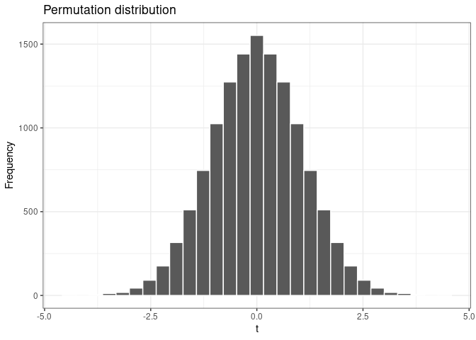

```r
tibble(t = permTs) %>% ggplot(aes(x = t)) +
  geom_histogram(color = "white") +
  labs(title = "Permutation distribution",
       y = "Frequency") +
  theme_bw()
```

```r
# The distribution is centered at 0
```

## Add vertical lines to the plot to indicate where the 5th percentile is (a red dotted line), and where our observed test statistic is (solid blue line).

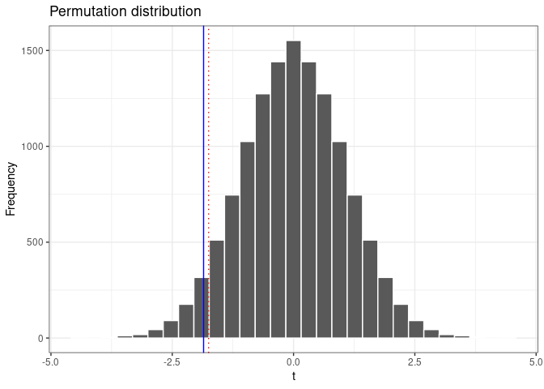

```r
tibble(t=permTs) %>% ggplot(aes(x=t))+
  geom_histogram(color="white")+
  geom_vline(xintercept=quantile(permTs, probs=0.05),
             color="red", linetype="dotted")+
  geom_vline(xintercept=tResult$statistic,
             color="blue", linetype="solid")+
  labs(title = "Permutation distribution",
       y="Frequency")+
  theme_bw()
```

## Calculate the p-value for the permutation test. In this case, the p-value can be calculated as the proportion of permutation test statistics less than or equal to our observed 𝑡-test statistic.

```r
permPvalue<-mean(permTs<=tResult$statistic)
permPvalue
```

```
## [1] 0.04048174
```

## Since the P-value of 0.0404817 is less than 0.05 that is we have evidence at the 5% significance level that our proposesd drug lowers peoples blood pressure more on average than just a placedo.

## Do we reject or fail to reject the null at the 5% significance level?

## Answer: Reject

# Bootstrapping

```r
# Simulating data from distribution
set.seed(1989)
n <- 30
observed <- rchisq(n = n, df = 4) + rnorm(n = n, mean = 0, sd = 1)
```

## Create a histogram to visualize the simulated data. Describe the data in terms of its number of peaks (e.g., unimodal, bimodal, etc.) and its symmetry.

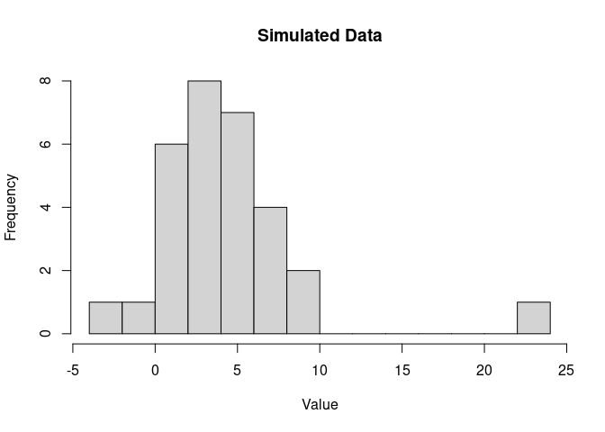

```r
# Create histogram
hist(observed, breaks = "FD", main = "Simulated Data", xlab = "Value")
```

```r
# Describe the data
# Calculate number of peaks
peaks <- function(x) {
  up <- diff(x) > 0
  down <- diff(x) < 0
  peaks <- diff(up) < 0 & diff(down) > 0
  sum(peaks)
}

num_peaks <- peaks(observed)

# Check symmetry
symmetry <- ifelse(skewness(observed) < 0.05, "approximately symmetric", "not symmetric")

# Print description
cat("Number of peaks:", num_peaks, "\n")
```

```
## Number of peaks: 8
```

```r
cat("Symmetry:", symmetry)
```

```
## Symmetry: not symmetric
```

## What is the sample size for this data set?

## Answer: 30

## What is the sample median for this data?

```r
median(observed)
```

```
## [1] 3.448628
```

```r
# Number of bootstrap samples
B <- 10000
# Instantiating matrix for bootstrap samples
boots <- matrix(NA, nrow = n, ncol = B)
# Sampling with replacement B times
for (b in 1:B) {
  boots[, b] <- observed[sample(1:n, size = n, replace = TRUE)]
}
```

## Using the generated bootstrap samples, create a bootstrap distribution of sample medians, and visualize this distribution using a histogram.

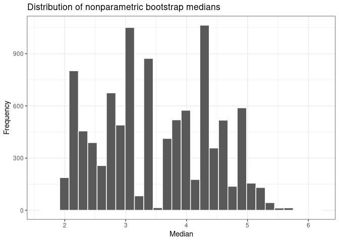

```r
#Installing vector for bootstrap medians
bootMedians<-vector(length=B)

#Calculating the median for each of the resamples
for(b in 1:B) {
  bootMedians[b]<-median(boots[,b])
}

#Creating a histogram
tibble(Median=bootMedians) %>% ggplot(aes(x=Median))+
  geom_histogram(color="white")+
  labs(title = "Distribution of nonparametric bootstrap medians",
       y="Frequency")+
  theme_bw()
```

## Use the bootstrap samples to obtain a nonparametric estimate of the standard error of the sample median.

```r
SEestimate<-sd(bootMedians)
SEestimate
```

```
## [1] 0.9040296
```

## Use the bootstrap samples to obtain a nonparametric 95%confidence interval for the sample median.

```r
quantile(bootMedians, probs=0.025)
```

```
##     2.5%
## 2.094548
```

```r
quantile(bootMedians, probs=0.975)
```

```
##    97.5%
## 5.071918
```

## 95% confident that the true median is between 2.09 and 5.07.

## Generate 𝐵 = 10, 000 samples from a normal distribution using the estimated mean and standard deviation from the observed data set, and visualize this distribution using a histogram.

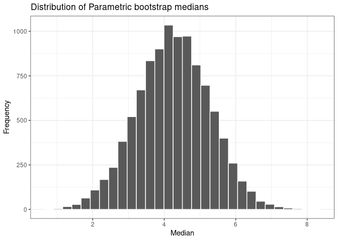

```r
# Number of bootstrap samples
B <- 10000

# Instantiating matrix for bootstrap samples
paramboots <- matrix(NA, nrow = n, ncol = B)
xBar<-mean(observed)
s<-sd(observed)

# Simulating a normal set of 30 values, B times
for(b in 1:B) {
paramboots[, b] <- rnorm(n=n, mean=xBar, sd=s)
}

#Installing vector for bootstrap medians
bootparamMedians<-vector(length=B)

#Calculating median for each simulated data set
for(b in 1:B) {
  bootparamMedians[b]<-median(paramboots[,b])
}

#Creating a histogram
tibble(Median=bootparamMedians) %>% ggplot(aes(x=Median))+
  geom_histogram(color="white")+
  labs(title = "Distribution of Parametric bootstrap medians",
       y="Frequency")+
  theme_bw()
```

```r
sd(bootMedians)
```

```
## [1] 0.9040296
```

```r
quantile(bootparamMedians, probs=0.05)
```

```
##       5%
## 2.597577
```

```r
quantile(bootparamMedians, probs=0.95)
```

```
##      95%
## 5.901328
```